# 2 Reproducibility of Curini and Vignoli (2021)

## 2.1 Background

In Curini and Vignoli (2021), the following regression table was reported (Figure 2.1).

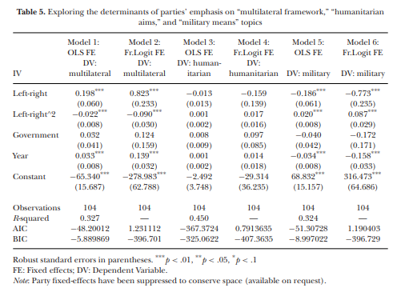

Figure 2.1: Original regression table in Curini and Vignoli (2021) (fair use)

Specifically, for model 2, the regression coefficient for Left-Right is **0.823**. In our multiverse analysis, however, this positive coefficient was not returned. We adopted the following R code shared on Harvard Dataverse: https://dataverse.harvard.edu/file.xhtml?fileId=4291432&version=1.0. The code, in verbatim, is following:

```r
rm(list=ls(all=TRUE))
# setwd("....") set your working directory where the legislative speech texts are stored

# to fully replicate our results you need to have installed the following two packages:
# "quanteda.seededlda_0.2" and "quanteda_1.5.1"

# to install "quanteda.seededlda_0.2":
# devtools::install_github("koheiw/seededlda", ref = "ad0c345a6f05d3cfefd15f3f108a03d7653791b2")

# to install "quanteda_1.5.1":
# devtools::install_github("quanteda/quanteda", ref = "v1.5.1")

# If you are using a quanteda version >2.0, and you want to avoid to install quanteda_1.5.1. (highly recommended),
# to replicate our results you can also simply load the "dfm.RData" Workspace.
# In this case, after having loaded such Workspace, you can avoid Step 1 and 2, and start the analysis directly since Step 3 below

require(quanteda)
require(readtext)
require(quanteda.seededlda)

####################################################
#### Step 1: open the texts
# IMPORTANT: the "zip_texts" archive file in Dataverse is a .rar file. Before running this script, please transform it from a .rar file to
# a .zip file. For example from here: https://www.convertfiles.com/convert/archive/RAR-to-ZIP.html
####################################################

myText <- readtext("zip_texts.zip",
docvarsfrom = "filenames", dvsep = "_", docvarnames = c("Party", "Mission"), encoding = "UTF-8")
names(myText)[1] <- "Name"
myText$Name <- gsub(".txt", "", myText$Name )

####################################################
#### Step 2: clean texts, creating corpus and then DfM
####################################################

myText$text <- gsub("[\u0092]","'",myText$text)
myText$text <- gsub("[\u2019]","'",myText$text)
myText$text <- gsub("[\u00b4]","'",myText$text)
myText$text <- gsub("[\u00d5]","'",myText$text)
myText$text <- gsub("[\u017e]","'",myText$text)
myText$text <- gsub("[\u017d]","'",myText$text)
myText$text <- gsub("[\u02c6]","'",myText$text)
myText$text <- gsub("[\u00ca]","'",myText$text)
myText$text <- gsub("[\u02dc]","'",myText$text)
myText$text <- gsub("[\u00c7]","'",myText$text)
myText$text <- gsub("'"," ",myText$text)

myText$text <- gsub("�no�","no",myText$text)
myText$text <-  gsub("�no�","no",myText$text)
myText$text <-  gsub("�No�","no",myText$text)

meta.pr <- read.csv("meta_table.csv", 1)
meta.pr$Name <- as.character(meta.pr$Name )
meta.pr <- meta.pr[,-2]
names(meta.pr)[4] <- "Mission_name"

fit <- merge(myText, meta.pr, by = "Name")
names(fit)[5] <- "LR"
fit <- fit[,-1]
fit$Party <- as.factor(fit$Party)
fit$Mission <-as.factor(fit$Mission )

corpus <- corpus(fit)
docnames(corpus) <- meta.pr$Name

myDfm <- dfm(corpus, remove = c(stopwords("italian"), "l", "d", "dell", "dall", "afganistan", "libano", "kosovo", "iraq", "libia", "albania")
, tolower = TRUE, stem = TRUE, remove_punct = TRUE, remove_numbers=TRUE)

###########################
### Step 3: define the word-seeds
###########################

myDict <- dictionary(list(multilateralism= c("multilateralism", "comunit", "responsabilit", "alleanza", "alleati", "impegno",
"sicurezza", "coalizione"),
   humanitarian_dimension= c("democrazia", "umani", "democrazia", "democratica", "diritto", "pace", "solidariet", "libert", "pacific*",
"umanitaria", "umanitari", "solidal*"),
   war= c("guerra", "militare", "bombardamenti", "militari", "costituzione", "disarmo", "chiarezza", "violenza", "bombe", "rischi",
"vittime")))

##########################
### Step 4: fitting the seeded LDA
##########################

set.seed(123)
slda <- textmodel_seededlda(myDfm, myDict, residual = TRUE)

# let's extract the coefficients for each topic across documents
multilateralism<- rep(NA, nrow(myText))
for (i in 1:104){
multilateralism[i] <- slda$lda@gamma[i,][1]
}

humanitarian_dimension <- rep(NA,  nrow(myText))
for (i in 1:104){
humanitarian_dimension [i] <- slda$lda@gamma[i,][2]
}

war <- rep(NA,  nrow(myText))
for (i in 1:104){
war  [i] <- slda$lda@gamma[i,][3]
}

fit_slda  <-fit[-c(1)]
fit_slda $multilateralism <- multilateralism
fit_slda $humanitarian_dimension<- humanitarian_dimension
fit_slda $war<- war

##########################
### Step 5: saving the results for the Stata analysis
##########################

write.csv(fit_slda, "scores_slda.csv")
```

**1**

The authors specifically asks for `quanteda` 1.5.1 and `quanteda.seededlda` 0.2.

**2**

The data shared on Dataverse is an RAR file.

**3**

The corpus `corpus` is created. The document-term matrix (or `dfm`) `myDfm` is also created. Please note that there are some additional words such as “afganistan”, “libano”, “kosovo”, “iraq”, “libia”, “albania” are considered stopwords.

**4**

The dictionary is defined. Please note that some words are not the same as reported in the paper (e.g., “multilateralism” vs “multilateralismo” in the paper).

**5**

The random seed is hardcoded to 123.

**6**

The output is saved as `scores_slda.csv` for further analysis in Stata.

Please note also that the work space dump was also shared: https://dataverse.harvard.edu/file.xhtml?fileId=4291438&version=1.0. In the dump, among other things, `corpus` and `myDfm` are included. In addition, the generated file `scores_slda.csv` was also shared.

We were asked to investigate what causes the discrepancy (the reported positive value in Curini and Vignoli (2021) and the negative values in our multiverse analysis). Indeed, we adopted the code but also introduced several changes.

1. We did not use Stata for the regression analysis.
2. We did not run the code using the same R packages. Specifically, we used more recent `quanteda` and `seededlda` (the successor package of `quanteda.seededlda` by the same author); and also a more recent version of R.
3. We used an Italian stemmer.

## 2.2 Plan

In this investigation, we construct a Docker image using the following Dockerfile that should represent a similar, if not the same, computational environment as what Curini and Vignoli (2021) was used for their analysis.

```
FROM ghcr.io/r-hub/evercran/3.6.1

RUN apt update ; apt install -y libxml2-dev libgsl-dev

RUN Rscript -e 'options(repos = c(CRAN = "https://packagemanager.posit.co/cran/2019-09-02/bin/linux/bookworm-x86_64/3.6")); install.packages(c("remotes", "sandwich", "lmtest", "here")); '

RUN Rscript -e 'options(repos = c(CRAN = "https://packagemanager.posit.co/cran/2019-09-02/bin/linux/bookworm-x86_64/3.6")); remotes::install_github("quanteda/quanteda", ref = "v1.5.1") ; remotes::install_github("koheiw/seededlda", ref = "ad0c345a6f05d3cfefd15f3f108a03d7653791b2"); library(quanteda); library(quanteda.seededlda)'

WORKDIR /root/multiverse_tm

CMD ["bash"]
```

With this Docker image, we launch a Docker container (Except Step 5) to run the original code and data shared by Curini and Vignoli (2021) on Dataverse. We modify one thing at a time, until we find out the discrepancy in the estimate. We can then establish a causal link between what has been changed and the irreproducibility of the originally reported estimate by Curini and Vignoli (2021), i.e. a positive estimate of **0.823**.

## 2.3 Step 1: Testing our translated R code for regression

```stata
reg multi100 c.lr##c.lr gov year i.code, r
```

```
part1.R
```

```r
suppressPackageStartupMessages(library(here))
suppressPackageStartupMessages(library(sandwich))
suppressPackageStartupMessages(library(lmtest))

reg_data <- read.csv(here("rawdata/scores_slda.csv"), stringsAsFactors = FALSE)

reg_data$multi100 <- reg_data$multilateralism /
    (reg_data$multilateralism + reg_data$humanitarian_dimension + reg_data$war)

glmmod <- glm(
    multi100 ~ LR + I(LR^2) + Gov + Year + as.factor(Party),
    data = reg_data,
    family = quasibinomial("logit")
)
print(coeftest(glmmod, vcov. = vcovHC(glmmod, type = "HC0")))
print(sessionInfo())
```

```bash
docker compose run --remove-orphans --rm r36 Rscript --vanilla "meta/curinidocker/part1.R"
#>  Container curinidocker-r36-run-a988b759d9ea Creating
#>  r36 IPv4 forwarding is disabled. Networking will not work.
#>  Container curinidocker-r36-run-a988b759d9ea Created
#>
#> z test of coefficients:
#>
#>                           Estimate  Std. Error z value  Pr(>|z|)
#> (Intercept)            -278.982660   62.484987 -4.4648 8.015e-06 ***
#> LR                        0.823304    0.231547  3.5557  0.000377 ***
#> I(LR^2)                  -0.090309    0.029538 -3.0574  0.002233 **
#> Gov                       0.124265    0.157914  0.7869  0.431330
#> Year                      0.139082    0.031459  4.4211 9.820e-06 ***
#> as.factor(Party)CCDCDU   -1.306378    0.611654 -2.1358  0.032695 *
#> as.factor(Party)DS       -0.959840    1.132417 -0.8476  0.396659
#> as.factor(Party)FI       -0.767191    0.406216 -1.8886  0.058942 .
#> as.factor(Party)IdV      -2.321411    1.111289 -2.0889  0.036714 *
#> as.factor(Party)LN       -0.394990    0.298696 -1.3224  0.186042
#> as.factor(Party)Mar      -0.971949    0.974729 -0.9971  0.318693
#> as.factor(Party)PD       -3.094915    1.239736 -2.4964  0.012545 *
#> as.factor(Party)PPI      -0.945015    0.901725 -1.0480  0.294635
#> as.factor(Party)PRC      -0.244930    1.287848 -0.1902  0.849164
#> as.factor(Party)PdCI     -0.328111    1.282215 -0.2559  0.798033
#> as.factor(Party)PdL      -2.458531    0.388732 -6.3245 2.541e-10 ***
#> as.factor(Party)UDC      -0.865712    0.634189 -1.3651  0.172231
#> as.factor(Party)Verdi    -1.103981    1.177870 -0.9373  0.348620
#> ---
#> Signif. codes:  0 '***' 0.001 '**' 0.01 '*' 0.05 '.' 0.1 ' ' 1
#>
#> R version 3.6.1 (2019-07-05)
#> Platform: x86_64-pc-linux-gnu (64-bit)
#> Running under: Debian GNU/Linux 12 (bookworm)
#>
#> Matrix products: default
#> BLAS:   /usr/lib/x86_64-linux-gnu/openblas-pthread/libblas.so.3
#> LAPACK: /usr/lib/x86_64-linux-gnu/openblas-pthread/libopenblasp-r0.3.21.so
#>
#> locale:
#> [1] C
#>
#> attached base packages:
#> [1] stats     graphics  grDevices utils     datasets  methods   base
#>
#> other attached packages:
#> [1] lmtest_0.9-37  zoo_1.8-6      sandwich_2.5-1 here_0.1
#>
#> loaded via a namespace (and not attached):
#> [1] compiler_3.6.1  backports_1.1.4 rprojroot_1.3-2 grid_3.6.1
#> [5] lattice_0.20-38
```

Indeed, the regression coefficient of LR is still positive and exactly the same.

## 2.4 Step 2: Testing the original seedlda code

As the regression code is not the reason for irreproducibility, it should be because of the text analysis step. As the original workspace dump was provided, we rerun here the analysis from the provided document-term matrix.

```
part2.R
```

```r
suppressPackageStartupMessages(library(here))
suppressPackageStartupMessages(library(sandwich))
suppressPackageStartupMessages(library(lmtest))
suppressPackageStartupMessages(library(quanteda))
suppressPackageStartupMessages(library(quanteda.seededlda))

load(here("rawdata/dfm.RData"))

cat("DFM version\n")
print(myDfm@version)

cat("Dimenions\n")
print(dim(myDfm))

myDict <- dictionary(list(
    multilateralism = c(
        "multilateralism",
        "comunit",
        "responsabilit",
        "alleanza",
        "alleati",
        "impegno",
        "sicurezza",
        "coalizione"
    ),
    humanitarian_dimension = c(
        "democrazia",
        "umani",
        "democrazia",
        "democratica",
        "diritto",
        "pace",
        "solidariet",
        "libert",
        "pacific*",
        "umanitaria",
        "umanitari",
        "solidal*"
    ),
    war = c(
        "guerra",
        "militare",
        "bombardamenti",
        "militari",
        "costituzione",
        "disarmo",
        "chiarezza",
        "violenza",
        "bombe",
        "rischi",
        "vittime"
    )
))

set.seed(123)

slda <- textmodel_seededlda(myDfm, myDict, residual = TRUE)
multilateralism <- rep(NA, nrow(myText))
for (i in 1:104) {
    multilateralism[i] <- slda$lda@gamma[i, ][1]
}

humanitarian_dimension <- rep(NA, nrow(myText))
for (i in 1:104) {
    humanitarian_dimension[i] <- slda$lda@gamma[i, ][2]
}

war <- rep(NA, nrow(myText))
for (i in 1:104) {
    war[i] <- slda$lda@gamma[i, ][3]
}

fit_slda <- fit[-c(1)]
fit_slda$multilateralism <- multilateralism
fit_slda$humanitarian_dimension <- humanitarian_dimension
fit_slda$war <- war

reg_data <- fit_slda

reg_data$multi100 <- reg_data$multilateralism /
    (reg_data$multilateralism + reg_data$humanitarian_dimension + reg_data$war)

glmmod <- glm(
    multi100 ~ LR + I(LR^2) + Gov + Year + as.factor(Party),
    data = reg_data,
    family = quasibinomial("logit")
)
print(coeftest(glmmod, vcov. = vcovHC(glmmod, type = "HC0")))
print(sessionInfo())
```

```bash
docker compose run --remove-orphans --rm r36 Rscript --vanilla "meta/curinidocker/part2.R"
#>  Container curinidocker-r36-run-d470c908ea82 Creating
#>  r36 IPv4 forwarding is disabled. Networking will not work.
#>  Container curinidocker-r36-run-d470c908ea82 Created
#> DFM version
#> [1] 1 5 1
#> Dimenions
#> [1]   104 17885
#>
#> z test of coefficients:
#>
#>                           Estimate  Std. Error z value  Pr(>|z|)
#> (Intercept)            -278.982660   62.484987 -4.4648 8.015e-06 ***
#> LR                        0.823304    0.231547  3.5557  0.000377 ***
#> I(LR^2)                  -0.090309    0.029538 -3.0574  0.002233 **
#> Gov                       0.124265    0.157914  0.7869  0.431330
#> Year                      0.139082    0.031459  4.4211 9.820e-06 ***
#> as.factor(Party)CCDCDU   -1.306378    0.611654 -2.1358  0.032695 *
#> as.factor(Party)DS       -0.959840    1.132417 -0.8476  0.396659
#> as.factor(Party)FI       -0.767191    0.406216 -1.8886  0.058942 .
#> as.factor(Party)IdV      -2.321411    1.111289 -2.0889  0.036714 *
#> as.factor(Party)LN       -0.394990    0.298696 -1.3224  0.186042
#> as.factor(Party)Mar      -0.971949    0.974729 -0.9971  0.318693
#> as.factor(Party)PD       -3.094915    1.239736 -2.4964  0.012545 *
#> as.factor(Party)PdCI     -0.328111    1.282215 -0.2559  0.798033
#> as.factor(Party)PdL      -2.458531    0.388732 -6.3245 2.541e-10 ***
#> as.factor(Party)PPI      -0.945015    0.901725 -1.0480  0.294635
#> as.factor(Party)PRC      -0.244930    1.287848 -0.1902  0.849164
#> as.factor(Party)UDC      -0.865712    0.634189 -1.3651  0.172231
#> as.factor(Party)Verdi    -1.103981    1.177870 -0.9373  0.348620
#> ---
#> Signif. codes:  0 '***' 0.001 '**' 0.01 '*' 0.05 '.' 0.1 ' ' 1
#>
#> R version 3.6.1 (2019-07-05)
#> Platform: x86_64-pc-linux-gnu (64-bit)
#> Running under: Debian GNU/Linux 12 (bookworm)
#>
#> Matrix products: default
#> BLAS:   /usr/lib/x86_64-linux-gnu/openblas-pthread/libblas.so.3
#> LAPACK: /usr/lib/x86_64-linux-gnu/openblas-pthread/libopenblasp-r0.3.21.so
#>
#> locale:
#> [1] C
#>
#> attached base packages:
#> [1] stats     graphics  grDevices utils     datasets  methods   base
#>
#> other attached packages:
#> [1] quanteda.seededlda_0.2 quanteda_1.5.1         lmtest_0.9-37
#> [4] zoo_1.8-6              sandwich_2.5-1         here_0.1
#>
#> loaded via a namespace (and not attached):
#>  [1] NLP_0.2-0          Rcpp_1.0.2         pillar_1.4.2       compiler_3.6.1
#>  [5] tools_3.6.1        stopwords_1.0      lubridate_1.7.4    tibble_2.1.3
#>  [9] gtable_0.3.0       lattice_0.20-38    pkgconfig_2.0.2    rlang_0.4.0
#> [13] Matrix_1.2-17      fastmatch_1.1-0    parallel_3.6.1     stringr_1.4.0
#> [17] xml2_1.2.2         topicmodels_0.2-8  stats4_3.6.1       rprojroot_1.3-2
#> [21] grid_3.6.1         data.table_1.12.2  ggplot2_3.2.1      spacyr_1.2
#> [25] magrittr_1.5       backports_1.1.4    scales_1.0.0       modeltools_0.2-22
#> [29] colorspace_1.4-1   stringi_1.4.3      RcppParallel_4.4.3 lazyeval_0.2.2
#> [33] munsell_0.5.0      slam_0.1-45        tm_0.7-6           crayon_1.3.4
```

Still, the regression coefficient of LR is still positive and exactly the same.

## 2.5 Step 3: Testing the original tokenization code

The original workspace dump contains also the corpus `corpus`. This step is almost the same as Step 2, only the original code for creating the document-term matrix is added.

```
part3.R
```

```r
suppressPackageStartupMessages(library(here))
suppressPackageStartupMessages(library(sandwich))
suppressPackageStartupMessages(library(lmtest))
suppressPackageStartupMessages(library(quanteda))
suppressPackageStartupMessages(library(quanteda.seededlda))

load(here("rawdata/dfm.RData"))

cat("DFM version\n")
print(myDfm@version)

cat("Dimenions\n")
print(dim(myDfm))

ori_terms <- colnames(myDfm)

myDict <- dictionary(list(
    multilateralism = c(
        "multilateralism",
        "comunit",
        "responsabilit",
        "alleanza",
        "alleati",
        "impegno",
        "sicurezza",
        "coalizione"
    ),
    humanitarian_dimension = c(
        "democrazia",
        "umani",
        "democrazia",
        "democratica",
        "diritto",
        "pace",
        "solidariet",
        "libert",
        "pacific*",
        "umanitaria",
        "umanitari",
        "solidal*"
    ),
    war = c(
        "guerra",
        "militare",
        "bombardamenti",
        "militari",
        "costituzione",
        "disarmo",
        "chiarezza",
        "violenza",
        "bombe",
        "rischi",
        "vittime"
    )
))

myDfm <- dfm(

    corpus,
    remove = c(

        stopwords("italian"),
        "l",
        "d",
        "dell",
        "dall",
        "afganistan",
        "libano",
        "kosovo",
        "iraq",
        "libia",
        "albania"
    ),
    tolower = TRUE,
    stem = TRUE,
    remove_punct = TRUE,
    remove_numbers = TRUE
)

cat("DFM version\n")
print(myDfm@version)

cat("Dimenions\n")
print(dim(myDfm))

cat("Missing terms in the newly created DFM \n")
print(setdiff(ori_terms, colnames(myDfm)))

set.seed(123)

slda <- textmodel_seededlda(myDfm, myDict, residual = TRUE)
multilateralism <- rep(NA, nrow(myText))
for (i in 1:104) {
    multilateralism[i] <- slda$lda@gamma[i, ][1]
}

humanitarian_dimension <- rep(NA, nrow(myText))
for (i in 1:104) {
    humanitarian_dimension[i] <- slda$lda@gamma[i, ][2]
}

war <- rep(NA, nrow(myText))
for (i in 1:104) {
    war[i] <- slda$lda@gamma[i, ][3]
}

fit_slda <- fit[-c(1)]
fit_slda$multilateralism <- multilateralism
fit_slda$humanitarian_dimension <- humanitarian_dimension
fit_slda$war <- war

reg_data <- fit_slda

reg_data$multi100 <- reg_data$multilateralism /
    (reg_data$multilateralism + reg_data$humanitarian_dimension + reg_data$war)

glmmod <- glm(
    multi100 ~ LR + I(LR^2) + Gov + Year + as.factor(Party),
    data = reg_data,
    family = quasibinomial("logit")
)
print(coeftest(glmmod, vcov. = vcovHC(glmmod, type = "HC0")))
print(sessionInfo())
```

**1**

The only line of code added compared to `part2.R`.

```bash
docker compose run --remove-orphans --rm r36 Rscript --vanilla "meta/curinidocker/part3.R"
#>  Container curinidocker-r36-run-1361fa05b683 Creating
#>  r36 IPv4 forwarding is disabled. Networking will not work.
#>  Container curinidocker-r36-run-1361fa05b683 Created
#> DFM version
#> [1] 1 5 1
#> Dimenions
#> [1]   104 17885
#> DFM version
#> [1] 1 5 1
#> Dimenions
#> [1]   104 17884
#> Missing terms in the newly created DFM
#> [1] "j.f"          "g8"           "g7"           "kanun.quanto" "www.verdi.it"
#>
#> z test of coefficients:
#>
#>                          Estimate Std. Error z value  Pr(>|z|)
#> (Intercept)            368.573954  65.072303  5.6641 1.478e-08 ***
#> LR                      -0.949475   0.193813 -4.8989 9.636e-07 ***
#> I(LR^2)                  0.110423   0.026809  4.1189 3.807e-05 ***
#> Gov                      0.125138   0.130518  0.9588  0.337672
#> Year                    -0.183896   0.032727 -5.6190 1.920e-08 ***
#> as.factor(Party)CCDCDU   1.329940   0.528157  2.5181  0.011800 *
#> as.factor(Party)DS       1.159061   1.013253  1.1439  0.252665
#> as.factor(Party)FI       0.811693   0.358904  2.2616  0.023723 *
#> as.factor(Party)IdV      2.247072   1.026452  2.1892  0.028585 *
#> as.factor(Party)LN       0.273427   0.238317  1.1473  0.251246
#> as.factor(Party)Mar      1.176114   0.901936  1.3040  0.192237
#> as.factor(Party)PD       3.337076   1.128839  2.9562  0.003115 **
#> as.factor(Party)PdCI    -0.273347   1.137310 -0.2403  0.810063
#> as.factor(Party)PdL      1.189418   0.394045  3.0185  0.002540 **
#> as.factor(Party)PPI      1.639745   0.782689  2.0950  0.036170 *
#> as.factor(Party)PRC     -0.380766   1.136170 -0.3351  0.737526
#> as.factor(Party)UDC      1.035209   0.564877  1.8326  0.066858 .
#> as.factor(Party)Verdi    0.790455   1.008609  0.7837  0.433211
#> ---
#> Signif. codes:  0 '***' 0.001 '**' 0.01 '*' 0.05 '.' 0.1 ' ' 1
#>
#> R version 3.6.1 (2019-07-05)
#> Platform: x86_64-pc-linux-gnu (64-bit)
#> Running under: Debian GNU/Linux 12 (bookworm)
#>
#> Matrix products: default
#> BLAS:   /usr/lib/x86_64-linux-gnu/openblas-pthread/libblas.so.3
#> LAPACK: /usr/lib/x86_64-linux-gnu/openblas-pthread/libopenblasp-r0.3.21.so
#>
#> locale:
#> [1] C
#>
#> attached base packages:
#> [1] stats     graphics  grDevices utils     datasets  methods   base
#>
#> other attached packages:
#> [1] quanteda.seededlda_0.2 quanteda_1.5.1         lmtest_0.9-37
#> [4] zoo_1.8-6              sandwich_2.5-1         here_0.1
#>
#> loaded via a namespace (and not attached):
#>  [1] NLP_0.2-0           Rcpp_1.0.2          pillar_1.4.2
#>  [4] compiler_3.6.1      tools_3.6.1         stopwords_1.0
#>  [7] lubridate_1.7.4     tibble_2.1.3        gtable_0.3.0
#> [10] lattice_0.20-38     pkgconfig_2.0.2     rlang_0.4.0
#> [13] Matrix_1.2-17       fastmatch_1.1-0     parallel_3.6.1
#> [16] stringr_1.4.0       xml2_1.2.2          topicmodels_0.2-8
#> [19] stats4_3.6.1        rprojroot_1.3-2     grid_3.6.1
#> [22] data.table_1.12.2   ggplot2_3.2.1       spacyr_1.2
#> [25] magrittr_1.5        SnowballC_0.6.0     ISOcodes_2019.04.22
#> [28] backports_1.1.4     scales_1.0.0        modeltools_0.2-22
#> [31] colorspace_1.4-1    stringi_1.4.3       RcppParallel_4.4.3
#> [34] lazyeval_0.2.2      munsell_0.5.0       slam_0.1-45
#> [37] tm_0.7-6            crayon_1.3.4
```

What we observe here is that the regression coefficient of LR is now negative. We also observe that the original code for creating the document-term matrix cannot reproduce the same document-term matrix in the workspace dump. Some terms that should not be included are there in the document-term matrix inside the workspace dump (e.g., “www.verdi.it”, it should be tokenized into “www”, “verdi”, “it”).

```
part3ita.R
```

```r
suppressPackageStartupMessages(library(here))
suppressPackageStartupMessages(library(sandwich))
suppressPackageStartupMessages(library(lmtest))
suppressPackageStartupMessages(library(quanteda))
suppressPackageStartupMessages(library(quanteda.seededlda))

load(here("rawdata/dfm.RData"))

cat("DFM version\n")
print(myDfm@version)

cat("Dimenions\n")
print(dim(myDfm))

ori_terms <- colnames(myDfm)

myDict <- dictionary(list(
    multilateralism = c(
        "multilateralism",
        "comunit",
        "responsabilit",
        "alleanza",
        "alleati",
        "impegno",
        "sicurezza",
        "coalizione"
    ),
    humanitarian_dimension = c(
        "democrazia",
        "umani",
        "democrazia",
        "democratica",
        "diritto",
        "pace",
        "solidariet",
        "libert",
        "pacific*",
        "umanitaria",
        "umanitari",
        "solidal*"
    ),
    war = c(
        "guerra",
        "militare",
        "bombardamenti",
        "militari",
        "costituzione",
        "disarmo",
        "chiarezza",
        "violenza",
        "bombe",
        "rischi",
        "vittime"
    )
))

quanteda_options(language_stemmer = "it")
myDfm <- dfm(
    corpus,
    remove = c(
        stopwords("italian"),
        "l",
        "d",
        "dell",
        "dall",
        "afganistan",
        "libano",
        "kosovo",
        "iraq",
        "libia",
        "albania"
    ),
    tolower = TRUE,
    stem = TRUE,
    remove_punct = TRUE,
    remove_numbers = TRUE
)

cat("DFM version\n")
print(myDfm@version)

cat("Dimenions\n")
print(dim(myDfm))

cat("Missing terms in the newly created DFM \n")
print(setdiff(ori_terms, colnames(myDfm)))

set.seed(123)

slda <- textmodel_seededlda(myDfm, myDict, residual = TRUE)
multilateralism <- rep(NA, nrow(myText))
for (i in 1:104) {
    multilateralism[i] <- slda$lda@gamma[i, ][1]
}

humanitarian_dimension <- rep(NA, nrow(myText))
for (i in 1:104) {
    humanitarian_dimension[i] <- slda$lda@gamma[i, ][2]
}

war <- rep(NA, nrow(myText))
for (i in 1:104) {
    war[i] <- slda$lda@gamma[i, ][3]
}

fit_slda <- fit[-c(1)]
fit_slda$multilateralism <- multilateralism
fit_slda$humanitarian_dimension <- humanitarian_dimension
fit_slda$war <- war

reg_data <- fit_slda

reg_data$multi100 <- reg_data$multilateralism /
    (reg_data$multilateralism + reg_data$humanitarian_dimension + reg_data$war)

glmmod <- glm(
    multi100 ~ LR + I(LR^2) + Gov + Year + as.factor(Party),
    data = reg_data,
    family = quasibinomial("logit")
)
print(coeftest(glmmod, vcov. = vcovHC(glmmod, type = "HC0")))
print(sessionInfo())
```

**1**

The only line of code added compared to `part3.R`. This line of code for setting an option could be in the initialization file (e.g., `.Rprofile`).